# Data summary of my five flux towers

# 2. Heatmap of measured NEE

```r
library(ggplot2)
library(lubridate)
library(tidyverse)
library(dplyr)

Alltowers <- Alltowers %>%
  mutate(year = as.integer(year(time)))
```

```r
Alltowers_summary <- Alltowers %>%
  group_by(ID, year) %>%
  summarise(share_measured = mean(NEE_VUT_REF_QC == 0, na.rm = TRUE))
```

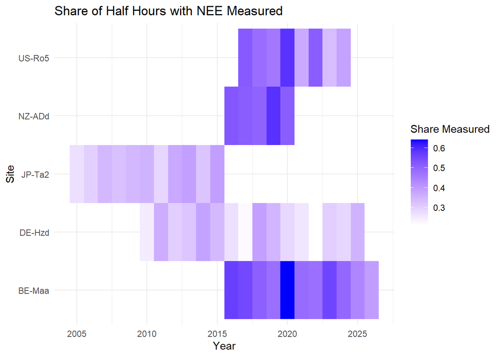

```r
#|fig-width: 8
#|fig-height: 5

library(ggplot2)

ggplot(Alltowers_summary, aes(x = year, y = ID, fill = share_measured)) +
  geom_tile() +
  scale_fill_gradient(low = "white", high = "blue") +
  labs(title = "Share of Half Hours with NEE Measured",
       x = "Year",
       y = "Site",
       fill = "Share Measured") +
  theme_minimal()
```

```r
best_data <- Alltowers_summary %>%
  filter(share_measured == max(share_measured, na.rm = TRUE))

best_data
```

```
# A tibble: 5 × 3
# Groups:   ID [5]
  ID      year share_measured
  <chr>  <int>          <dbl>
1 BE-Maa  2020          0.643
2 DE-Hzd  2018          0.390
3 JP-Ta2  2015          0.391
4 NZ-ADd  2019          0.590
5 US-Ro5  2020          0.589
```

The site in Belgium (Be-Maa) in 2020 has the best data with a share of 64.3% of half hours with NEE measured.

# Summary statistics

```r
summary_table <- Alltowers %>%
  group_by(ID) %>%
  summarise(
    across(c(TA_F, SW_IN_F, VPD_F, NEE_VUT_REF, GPP_NT_VUT_REF, RECO_NT_VUT_REF, H_F_MDS, LE_F_MDS),
           list(
             Mean = ~ mean(.x, na.rm = TRUE),
             Min = ~ min(.x, na.rm = TRUE),
             Max = ~ max(.x, na.rm = TRUE),
             Missing_pct = ~ sum(is.na(.x)) / n() * 100
           ), .names = "{.col} ({.fn})"),
    P_F_annual_sum = sum(P_F, na.rm = TRUE) * 24 * 365,
    P_F_min = min(P_F, na.rm = TRUE),
    P_F_max = max(P_F, na.rm = TRUE),
    P_F_missing_pct = sum(is.na(P_F)) / n() * 100
  )

colnames(summary_table) <- c(
  "Site (ID)",
  "TA_F (°C) Mean", "TA_F (°C) Min", "TA_F (°C) Max", "TA_F (%) Missing",
  "SW_IN_F (W/m²) Mean", "SW_IN_F (W/m²) Min", "SW_IN_F (W/m²) Max", "SW_IN_F (%) Missing",
  "VPD_F (kPa) Mean", "VPD_F (kPa) Min", "VPD_F (kPa) Max", "VPD_F (%) Missing",
  "NEE_VUT_REF (µmol/m²/s) Mean", "NEE_VUT_REF (µmol/m²/s) Min", "NEE_VUT_REF (µmol/m²/s) Max", "NEE_VUT_REF (%) Missing",
  "GPP_NT_VUT_REF (gC/m²/day) Mean", "GPP_NT_VUT_REF (gC/m²/day) Min", "GPP_NT_VUT_REF (gC/m²/day) Max", "GPP_NT_VUT_REF (%) Missing",
  "RECO_NT_VUT_REF (gC/m²/day) Mean", "RECO_NT_VUT_REF (gC/m²/day) Min", "RECO_NT_VUT_REF (gC/m²/day) Max", "RECO_NT_VUT_REF (%) Missing",
  "H_F_MDS (W/m²) Mean", "H_F_MDS (W/m²) Min", "H_F_MDS (W/m²) Max", "H_F_MDS (%) Missing",
  "LE_F_MDS (W/m²) Mean", "LE_F_MDS (W/m²) Min", "LE_F_MDS (W/m²) Max", "LE_F_MDS (%) Missing",
  "P_F (mm) Annual Sum", "P_F (mm) Min", "P_F (mm) Max", "P_F (%) Missing"
)

summary_table
```

```
# A tibble: 5 × 37
  `Site (ID)` `TA_F (°C) Mean` `TA_F (°C) Min` `TA_F (°C) Max`
  <chr>                  <dbl>           <dbl>           <dbl>
1 BE-Maa                 11.1           -12.6             40.0
2 DE-Hzd                  9.79          -21.4             36.2
3 JP-Ta2                  9.30          -13.8             33.0
4 NZ-ADd                 11.7            -4.34            33.9
5 US-Ro5                  7.71          -37.1             37.3
# ℹ 33 more variables: `TA_F (%) Missing` <dbl>, `SW_IN_F (W/m²) Mean` <dbl>,
#   `SW_IN_F (W/m²) Min` <dbl>, `SW_IN_F (W/m²) Max` <dbl>,
#   `SW_IN_F (%) Missing` <dbl>, `VPD_F (kPa) Mean` <dbl>,
#   `VPD_F (kPa) Min` <dbl>, `VPD_F (kPa) Max` <dbl>,
#   `VPD_F (%) Missing` <dbl>, `NEE_VUT_REF (µmol/m²/s) Mean` <dbl>,
#   `NEE_VUT_REF (µmol/m²/s) Min` <dbl>, `NEE_VUT_REF (µmol/m²/s) Max` <dbl>,
#   `NEE_VUT_REF (%) Missing` <dbl>, `GPP_NT_VUT_REF (gC/m²/day) Mean` <dbl>, …
```

# 4. Time Series of NEE, GPP and Reco

```r
library(dplyr)
library(ggplot2)
library(lubridate)

Alltowers_daily <- Alltowers %>%
  mutate(date = ymd_hm(TIMESTAMP_START)) %>%
  group_by(date = as.Date(date), ID) %>%
  summarise(
    NEE_daily = mean(NEE_VUT_REF, na.rm = TRUE) * 1.0378,
    GPP_daily = mean(GPP_NT_VUT_REF, na.rm = TRUE) * 1.0378,
    RECO_daily = mean(RECO_NT_VUT_REF, na.rm = TRUE) * 1.0378,
    .groups = 'drop'
  )

Alltowers_daily_long <- Alltowers_daily %>%
  pivot_longer(cols = c(NEE_daily, GPP_daily, RECO_daily),
               names_to = "Variable",
               values_to = "Value")
```

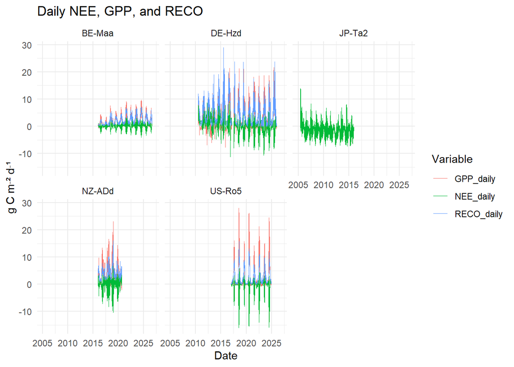

```r
#|fig-width: 10
#|fig-height: 5

ggplot(Alltowers_daily_long, aes(x = date, y = Value, color = Variable)) +
  geom_line(linewidth = 0.05) +
  facet_wrap(~ ID) +
  labs(title = "Daily NEE, GPP, and RECO",
       x = "Date",
       y = "g C m⁻² d⁻¹") +
  theme_minimal()
```

# 6

```r
Alltowers <- Alltowers %>%
  left_join(
    stations %>%
      select(ID, lat, lon),
    by = "ID") %>%
    mutate(
    time = ymd_hm(TIMESTAMP_START),
    hour = hour(time) + minute(time) / 60,
    month = month(time))

Alltowers <- Alltowers %>%
  mutate(
    month = lubridate::month(time),

    season = case_when(
      is.na(lat) ~ NA_character_,

      lat >= 0 & month %in% c(12, 1, 2) ~ "Winter",
      lat >= 0 & month %in% c(3, 4, 5) ~ "Spring",
      lat >= 0 & month %in% c(6, 7, 8) ~ "Summer",
      lat >= 0 & month %in% c(9, 10, 11) ~ "Autumn",

      lat < 0 & month %in% c(12, 1, 2) ~ "Summer",
      lat < 0 & month %in% c(3, 4, 5) ~ "Autumn",
      lat < 0 & month %in% c(6, 7, 8) ~ "Winter",
      lat < 0 & month %in% c(9, 10, 11) ~ "Spring"
    ),

    season = factor(
      season,
      levels = c("Spring", "Summer", "Autumn", "Winter")
    )
  )

hourly_long <- Alltowers %>%
  filter(!is.na(season)) %>%
  group_by(ID, season, hour) %>%
  summarise(
    NEE = mean(NEE_VUT_REF, na.rm = TRUE),
    LE  = mean(LE_F_MDS, na.rm = TRUE),
    .groups = "drop"
  ) %>%
  pivot_longer(
    cols = c(NEE, LE),
    names_to = "variable",
    values_to = "value"
  )
```

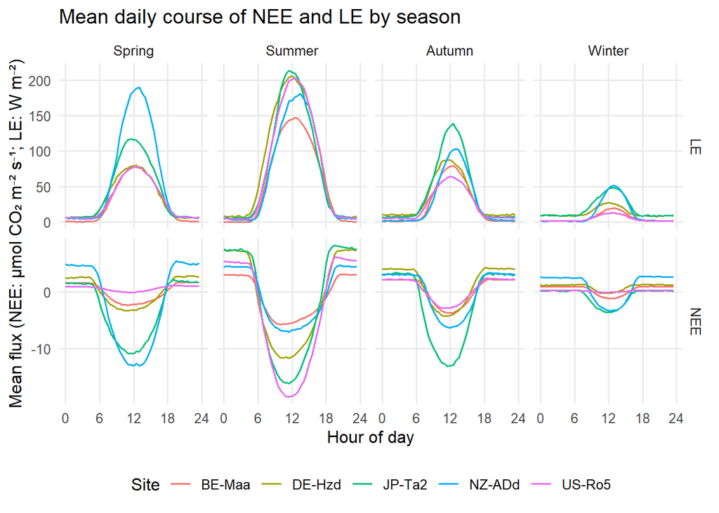

```r
#|fig-width: 10
#|fig-height: 5
ggplot( hourly_long, aes(x = hour, y = value, colour = ID, group = ID)) +
  geom_line(linewidth = 0.7) +
  facet_grid(variable ~ season, scales = "free_y") +
  scale_x_continuous(
    breaks = seq(0, 24, 6),
    limits = c(0, 24)) +
  labs(
    x = "Hour of day",
    y = "Mean flux (NEE: µmol CO₂ m⁻² s⁻¹; LE: W m⁻²)",
    colour = "Site",
    title = "Mean daily course of NEE and LE by season"
  ) +
  theme_minimal(base_size = 12) +
  theme(
    legend.position = "bottom",
    panel.grid.minor = element_blank()
  )
```

I added the latitude of each site from the stations table using the site ID. I used latitude to check whether each site is north or south of the equator: positive values mean north and negative values mean south. I assigned seasons based on the month, reversing them for sites in the Southern Hemisphere. Like that, December–February is winter in the Northern Hemisphere but summer in the Southern Hemisphere.

# 6

```r
energy_data <- Alltowers %>%
  filter(
    H_F_MDS_QC == 0,
    LE_F_MDS_QC == 0,
    is.finite(H_F_MDS),
    is.finite(LE_F_MDS),
    is.finite(NETRAD),
    is.finite(G_F_MDS)
  ) %>%
  mutate(
    available_energy = NETRAD - G_F_MDS,
    turbulent_flux = H_F_MDS + LE_F_MDS
  )


energy_site <- energy_data %>%
  filter(ID == "US-Ro5")

fit <- lm(turbulent_flux ~ available_energy, data = energy_site)
summary(fit)
```

```
Call:
lm(formula = turbulent_flux ~ available_energy, data = energy_site)

Residuals:
    Min      1Q  Median      3Q     Max
-340.66  -12.45   -1.25   13.29  292.06

Coefficients:
                 Estimate Std. Error t value Pr(>|t|)
(Intercept)      9.487548   0.098630   96.19   <2e-16 ***
available_energy 0.568844   0.000582  977.34   <2e-16 ***
---
Signif. codes:  0 '***' 0.001 '**' 0.01 '*' 0.05 '.' 0.1 ' ' 1

Residual standard error: 30.39 on 107325 degrees of freedom
Multiple R-squared:  0.899, Adjusted R-squared:  0.899
F-statistic: 9.552e+05 on 1 and 107325 DF,  p-value: < 2.2e-16
```

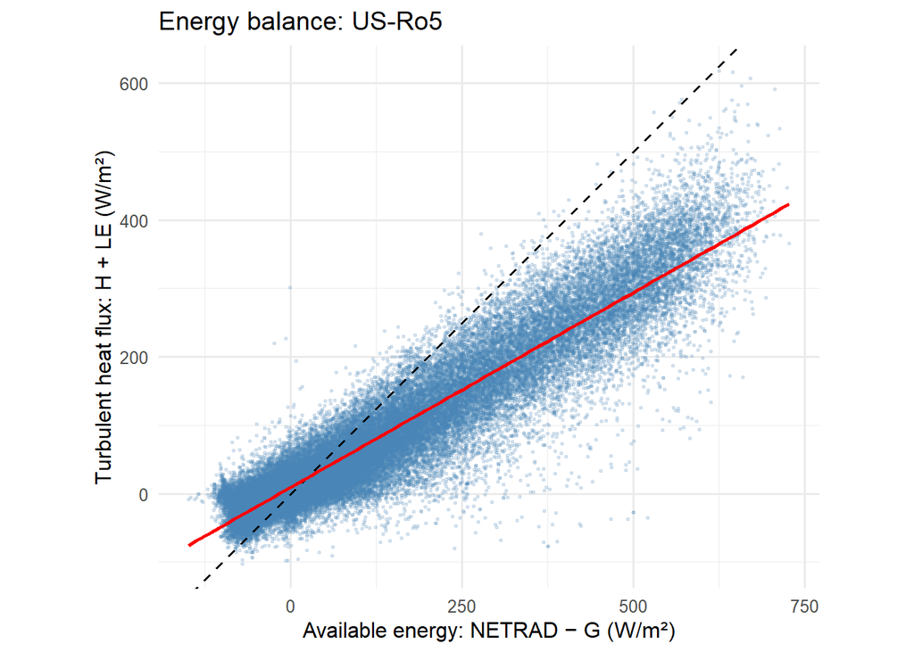

```r
#|fig-width: 8
#|fig-height: 5

ggplot(
  energy_site,
  aes(x = available_energy, y = turbulent_flux)) +
  geom_point(alpha = 0.15, size = 0.6, colour = "steelblue") +
  geom_abline(slope = 1,
    intercept = 0,
    linetype = "dashed",
    colour = "black") +
  geom_smooth(method = "lm",
    formula = y ~ x,
    se = FALSE,
    colour = "red",
    linewidth = 0.9) +
  coord_equal() +
  labs(title = paste("Energy balance: US-Ro5"),
    x = "Available energy: NETRAD − G (W/m²)",
    y = "Turbulent heat flux: H + LE (W/m²)") +
  theme_minimal(base_size = 12)
```

Not all of the available energy goes into latent and sensible heat flux. Some of the energy will i.e. be reflected (Albedo) or used for photosynthesis.

```r
annual_carbon <- Alltowers %>%
  group_by(ID, year) %>%
  summarise(
    n_rows = n(),
    n_times = n_distinct(time),
    n_NEE = sum(is.finite(NEE_VUT_REF)),
    NEE_gC_m2_year = sum(
      NEE_VUT_REF * 1800 * 12.011 / 1e6,
      na.rm = TRUE
    ),
    .groups = "drop"
  ) %>%
  mutate(
    expected_half_hours = if_else(
      leap_year(year), 366L, 365L
    ) * 48L,
    complete_year =
      n_rows == expected_half_hours &
      n_times == expected_half_hours &
      n_NEE == expected_half_hours
  )

print(annual_carbon)
```

```
# A tibble: 51 × 8
   ID      year n_rows n_times n_NEE NEE_gC_m2_year expected_half_hours
   <chr>  <int>  <int>   <int> <int>          <dbl>               <int>
 1 BE-Maa  2016  17568   17568 17568         -75.5                17568
 2 BE-Maa  2017  17520   17520 17520         -18.1                17520
 3 BE-Maa  2018  17520   17520 16018          55.8                17520
 4 BE-Maa  2019  17520   17520 17320         -20.9                17520
 5 BE-Maa  2020  17568   17568 17568           7.89               17568
 6 BE-Maa  2021  17520   17520 17520           9.37               17520
 7 BE-Maa  2022  17520   17520 17520          31.4                17520
 8 BE-Maa  2023  17520   17520 17520          17.7                17520
 9 BE-Maa  2024  17568   17568 17568         -23.8                17568
10 BE-Maa  2025  17520   17520 17520           6.71               17520
# ℹ 41 more rows
# ℹ 1 more variable: complete_year <lgl>
```

```r
carbon_summary <- annual_carbon %>%
  filter(complete_year) %>%
  group_by(ID) %>%
  summarise(
    n_complete_years = n(),
    mean_annual_NEE = mean(NEE_gC_m2_year),
    mean_annual_uptake = -mean_annual_NEE,
    .groups = "drop"
  ) %>%
  arrange(desc(mean_annual_uptake))
```

```r
monthly_NEE <- Alltowers %>%
  filter(is.finite(NEE_VUT_REF)) %>%
  group_by(ID, year, month) %>%
  summarise(
    monthly_NEE = mean(NEE_VUT_REF),
    .groups = "drop"
  ) %>%
  group_by(ID, month) %>%
  summarise(
    mean_monthly_NEE = mean(monthly_NEE),
    .groups = "drop"
  )

seasonal_summary <- monthly_NEE %>%
  group_by(ID) %>%
  summarise(
    n_months = n(),
    seasonal_amplitude = if (n() == 12L) {
      max(mean_monthly_NEE) - min(mean_monthly_NEE)
    } else {
      NA_real_
    },
    .groups = "drop"
  )
```

```r
gap_summary <- Alltowers %>%
  transmute(
    ID,
    NEE_value = NEE_VUT_REF,
    NEE_qc = NEE_VUT_REF_QC,
    LE_value = LE_F_MDS,
    LE_qc = LE_F_MDS_QC,
    H_value = H_F_MDS,
    H_qc = H_F_MDS_QC
  ) %>%
  pivot_longer(
    cols = -ID,
    names_to = c("variable", ".value"),
    names_pattern = "(NEE|LE|H)_(value|qc)"
  ) %>%
  group_by(ID, variable) %>%
  summarise(
    n_total = n(),
    n_missing = sum(!is.finite(value)),
    n_classified = sum(
      is.finite(value) & qc %in% 0:3
    ),
    n_gapfilled = sum(
      is.finite(value) & qc %in% 1:3
    ),
    .groups = "drop"
  ) %>%
  mutate(
    gapfilled_percent = if_else(
      n_classified > 0,
      100 * n_gapfilled / n_classified,
      NA_real_
    ),
    missing_percent = 100 * n_missing / n_total
  )

comparison <- carbon_summary %>%
  full_join(seasonal_summary, by = "ID") %>%
  left_join(
    gap_summary %>%
      filter(variable == "NEE") %>%
      select(ID, NEE_gapfilled_percent = gapfilled_percent),
    by = "ID"
  )

print(comparison)
```

```
# A tibble: 5 × 7
  ID     n_complete_years mean_annual_NEE mean_annual_uptake n_months
  <chr>             <int>           <dbl>              <dbl>    <int>
1 JP-Ta2               10         -726.               726.         12
2 US-Ro5                8         -214.               214.         12
3 NZ-ADd                4         -148.               148.         12
4 DE-Hzd                8          -51.5               51.5        12
5 BE-Maa                8           -5.54               5.54       12
# ℹ 2 more variables: seasonal_amplitude <dbl>, NEE_gapfilled_percent <dbl>
```

The site in Japan (JP-Ta2) has the strongest carbon uptake of all ecosystems. As an evergreen needleleaf forest this makes sense and alligns with the NEE plots on FLuxnet site explorer showing negative NEE values (carbon uptake) almost without seasonal carbon release as would be expected from broadleaf forests. The Germany site (De-Hzd) which is a broadleaf forest shows much lower carbon uptake. That might be due to heat and drought events in central Europe (especially eastern Germany) of the last 10 years. The US site (Us-Ro5) shows the strongest seasonal amplitude which makes sense because it is the only cropland area of the 5 sites showing strong uptake in the growing season and low - no carbon release after harvest. For all 5 towers at between 45 - 70 % of the data is gap-filled.66 and 69 % of gap-filling in Germany and Japan suggests some trouble with data aquisition for those towers.

# References

1. Pastorello et al. (2020), Scientific Data 7, 225, https://doi.org/10.1038/s41597-020-0534-3
2. DE-Hzd: Bernhofer, C., Eichelmann, U., Gruenwald, T., Hehn, M., Mauder, M., Moderow, U., Prasse, H. (2026). Fluxnet Archive Product from Hetzdorf, 2010–2025, FLUXNET, https://hdl.handle.net/11676/0bxipd79PBLdqj1HiB_ghXvT
3. JP-Ta2: Saitoh, T.M., Tamagawa, I. (2026). Fluxnet Archive Product from Takayama evergreen coniferous forest site, 2005–2015, FLUXNET, https://hdl.handle.net/11676/CmfB4bc3xT3z8lqsrgqLbIGm
4. NZ-ADd: Laubach, J., Hunt, J. (2026): Ashley Dene Dry FLUXNET Release 2026_r1. Version 2026_r1. Terrestrial Ecosystem Research Network (TERN). (Dataset).
5. US-Ro5: John Baker, Tim Griffis (2025), AmeriFlux FLUXNET-1F US-Ro5 Rosemount I18_South, Ver. v1.3_r1 (2017-2024), AmeriFlux AMP, (Dataset). https://doi.org/10.17190/AMF/1818371
6. BE-Maa: Roland, M., Bresseleers, S., De Meulder, T., Lefevre, L., Naseer, M., Segers, J., Van Look, J., Vande Sompele, A. (2026). Fluxnet Archive Product from Maasmechelen, 2016-01-01–2026-09-06, FLUXNET, https://hdl.handle.net/11676/msdWDk98FR3UQUqS9OM2N32V
7. Acknowledgement: FLUXNET data products were produced and harmonized by eddy covariance regional networks and data processing centers, including AmeriFlux, ChinaFlux, European Fluxes Database, ICOS, JapanFlux, KoFlux, OzFlux, SAEON, and TERN. These products also include a modified version of ERA5 hourly data provided by the Copernicus Climate Change Service.